# Práctica 1: Estadística descriptiva

Estadística - Curso 2023/2024

# Introducción y definición de objetivos

En este estudio los datos que analizaremos serán los obtenidos de pacientes en el hospital que pueden o no haber tenido un ataque al corazón. Este análisis nos indicará la relación, si existe, de distintas variables típicas que pueden influir en un ataque cardíaco con la edad y el sexo.

# Importación de datos y carga de paquetes

```r
heart <- read.csv("heart.csv")
library(tidyverse)
library(summarytools)
library(GGally)
library(dplyr)
library(ggplot2)
library(knitr)
```

# Diccionario de datos

- `age`: Edad (numérica).
- `sex`: Sexo (categórica, 0: Mujer, 1: Hombre).
- `chol`: Colesterol sérico (numérica).
- `trestbps`: Presión arterial en reposo (numérica).
- `thalach`: Frecuencia cardíaca máxima alcanzada (numérica).
- `oldpeak`: Depresión ST, alteraciones cardíacas (numérica).
- `target`: Porcentaje de riesgo de ataques al corazón en pacientes (numérica).
- `cp`: Tipo de dolor en el pecho (categórica, 0: Angina típica, 1: Angina atípica, 2: Dolor no anginoso, 3: Asintomático).
- `fbs`: Azúcar en sangre en ayunas (categórica, 0: <= 120 mg/dL, 1: > 120 mg/dL).
- `restecg`: Resultados electrocardiográficos en reposo (categórica, 0 : Normal, 1: Anormalidad, 2: Hipertrofia).
- `exang`: Angina inducida por el ejercicio (categórica, 0: No, 1: Sí).
- `slope`: Pendiente del segmento ST de ejercicio máximo (categórica, 0: ascendente, 1: plano, 2: descendente).
- `ca`: Número de vasos principales coloreados por fluoroscopia (numérica).
- `thal`: Talasemia (categórica, 0: normal, 1: defecto fijo, 2: defecto reversible).

Asignaremos a la variable nombre_variables los nombres de las variables en el conjunto de datos heart.

```r
nombre_variables <- names(heart)
```

# Análisis exploratorio de datos

## Datos univariantes

### Tablas de frecuencias

Se reducen los datos originales, clasificándolos por grupos y se calcula la frecuencia de cada grupo. Se dividen las variables numéricas chol, trestbps, thalach, oldpeak y target en ocho para crear los intervalos (rango_).

```r
heart_reducida <- heart |>
  mutate(rango_edades=cut(age,breaks =8),
         rango_colesterol=cut(chol,breaks=8),
         rango_presion_arterial=cut(trestbps, breaks =8),
         rango_frec_cardíaca_max=cut(thalach,breaks=8),
         rango_depresion=cut(oldpeak,breaks=8),
         rango_target=cut(target,breaks=8))
```

Se cuenta la frecuencia de combinaciones de valores de las variables seleccionadas.

```r
count(rango_edades,
        rango_colesterol,
        sex,
        cp,
        rango_presion_arterial,
        fbs,
        restecg,
        rango_frec_cardíaca_max,
        exang,
        rango_depresion,
        slope,
        ca,
        thal,
        rango_target)
```

[output not shown]

Se realiza un conteo total del sexo (1 para hombres, 0 para mujeres) y de la edad, se guarda en una tabla en un dataframe (uno para el sexo y otro para la edad).

```r
sexo<-as.data.frame(table(heart$sex))
edad<-as.data.frame(table(heart$age))
```

Se calcula la frecuencia acumulada, absoluta, relativa de la edad y el sexo.

```r
tabla_frecuencias_edad<- transform(edad,
                                   Frec_acumulada=cumsum(edad$Freq),
                                   Frec_relativa=round(prop.table(edad$Freq),3),
                                   Frec_rel_acumulada=round(cumsum(prop.table(edad$Freq)),3))
kable(tabla_frecuencias_edad)
```

| Var1 | Freq | Frec_acumulada | Frec_relativa | Frec_rel_acumulada |
| --- | --- | --- | --- | --- |
| 29 | 4 | 4 | 0.004 | 0.004 |
| 34 | 6 | 10 | 0.006 | 0.010 |
| 35 | 15 | 25 | 0.015 | 0.024 |
| 37 | 6 | 31 | 0.006 | 0.030 |
| 38 | 12 | 43 | 0.012 | 0.042 |
| 39 | 14 | 57 | 0.014 | 0.056 |
| 40 | 11 | 68 | 0.011 | 0.066 |
| 41 | 32 | 100 | 0.031 | 0.098 |
| 42 | 26 | 126 | 0.025 | 0.123 |
| 43 | 26 | 152 | 0.025 | 0.148 |
| 44 | 36 | 188 | 0.035 | 0.183 |
| 45 | 25 | 213 | 0.024 | 0.208 |
| 46 | 23 | 236 | 0.022 | 0.230 |
| 47 | 18 | 254 | 0.018 | 0.248 |
| 48 | 23 | 277 | 0.022 | 0.270 |
| 49 | 17 | 294 | 0.017 | 0.287 |
| 50 | 21 | 315 | 0.020 | 0.307 |
| 51 | 39 | 354 | 0.038 | 0.345 |
| 52 | 43 | 397 | 0.042 | 0.387 |
| 53 | 26 | 423 | 0.025 | 0.413 |
| 54 | 53 | 476 | 0.052 | 0.464 |
| 55 | 30 | 506 | 0.029 | 0.494 |
| 56 | 39 | 545 | 0.038 | 0.532 |
| 57 | 57 | 602 | 0.056 | 0.587 |
| 58 | 68 | 670 | 0.066 | 0.654 |
| 59 | 46 | 716 | 0.045 | 0.699 |
| 60 | 37 | 753 | 0.036 | 0.735 |
| 61 | 31 | 784 | 0.030 | 0.765 |
| 62 | 37 | 821 | 0.036 | 0.801 |
| 63 | 32 | 853 | 0.031 | 0.832 |
| 64 | 34 | 887 | 0.033 | 0.865 |
| 65 | 27 | 914 | 0.026 | 0.892 |
| 66 | 25 | 939 | 0.024 | 0.916 |
| 67 | 31 | 970 | 0.030 | 0.946 |
| 68 | 12 | 982 | 0.012 | 0.958 |
| 69 | 9 | 991 | 0.009 | 0.967 |
| 70 | 14 | 1005 | 0.014 | 0.980 |
| 71 | 11 | 1016 | 0.011 | 0.991 |
| 74 | 3 | 1019 | 0.003 | 0.994 |
| 76 | 3 | 1022 | 0.003 | 0.997 |
| 77 | 3 | 1025 | 0.003 | 1.000 |

```r
tabla_frecuencias_sex<- transform(sexo,
                                  Frec_acumulada=cumsum(sexo$Freq),
                                  Frec_relativa=round(prop.table(sexo$Freq),3),
                                  Frec_rel_acumulada=round(cumsum(prop.table(sexo$Freq)),3))
kable(tabla_frecuencias_sex)
```

| Var1 | Freq | Frec_acumulada | Frec_relativa | Frec_rel_acumulada |
| --- | --- | --- | --- | --- |
| 0 | 312 | 312 | 0.304 | 0.304 |
| 1 | 713 | 1025 | 0.696 | 1.000 |

### Gráficos de barras e histogramas

NOTA: Algunos gráficos no se han representado debido a que, por sí solas, esas variables no tenían sentido o significado, para que lo tuviesen era necesario compararlas con la edad o con el sexo.

#### Colesterol sérico

Gráfico de barras del colesterol:

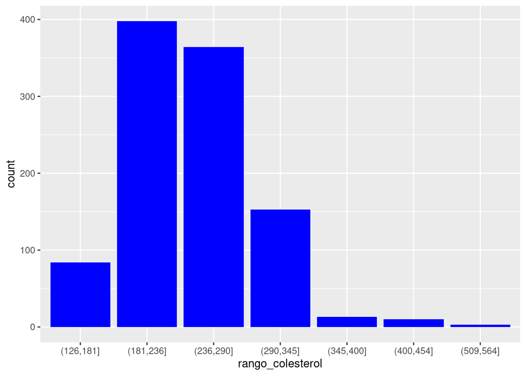

```r
heart_reducida |>
  ggplot(aes(rango_colesterol)) +
  geom_bar(fill = "blue")
```

```r
heart |> descr(chol)
```

```
## Descriptive Statistics
## heart$chol
## N: 1025
##
##                        chol
## ----------------- ---------
##              Mean    246.00
##           Std.Dev     51.59
##               Min    126.00
##                Q1    211.00
##            Median    240.00
##                Q3    275.00
##               Max    564.00
##               MAD     48.93
##               IQR     64.00
##                CV      0.21
##          Skewness      1.07
##       SE.Skewness      0.08
##          Kurtosis      3.96
##           N.Valid   1025.00
##         Pct.Valid    100.00
```

#### Presión arterial en reposo

Gráfico de barras de la presión arterial:

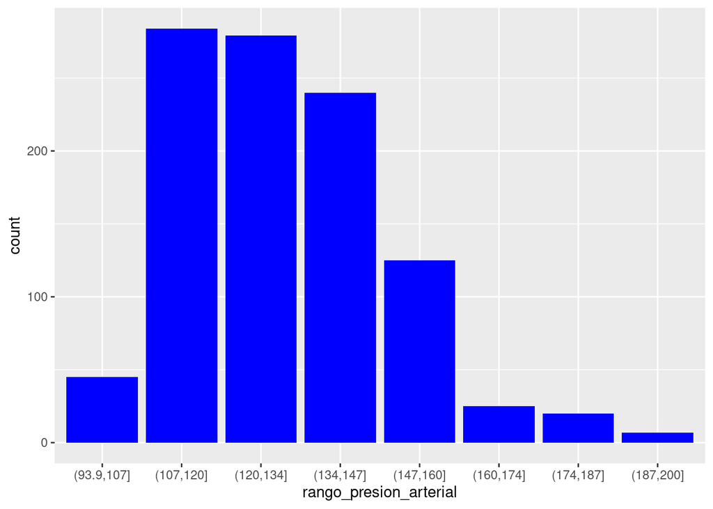

```r
heart_reducida |>
  ggplot(aes(rango_presion_arterial)) +
  geom_bar(fill = "blue")
```

```r
heart |> descr(trestbps)
```

```
## Descriptive Statistics
## heart$trestbps
## N: 1025
##
##                     trestbps
## ----------------- ----------
##              Mean     131.61
##           Std.Dev      17.52
##               Min      94.00
##                Q1     120.00
##            Median     130.00
##                Q3     140.00
##               Max     200.00
##               MAD      14.83
##               IQR      20.00
##                CV       0.13
##          Skewness       0.74
##       SE.Skewness       0.08
##          Kurtosis       0.97
##           N.Valid    1025.00
##         Pct.Valid     100.00
```

En esta gráfica representamos los distintos rangos de valores de la presión arterial frente al número de personas analizadas. La mayoría de personas presentan unos valores de presión entre 107 y 120 que se encontrarían en los valores normales. Tambien hay un número elevado de personas que presentan hipertensión, que causa problemas de corazón. Estas personas se encuentran entre el rango [130,180].

#### Depresión ST

Gráfico de barras de la depresión:

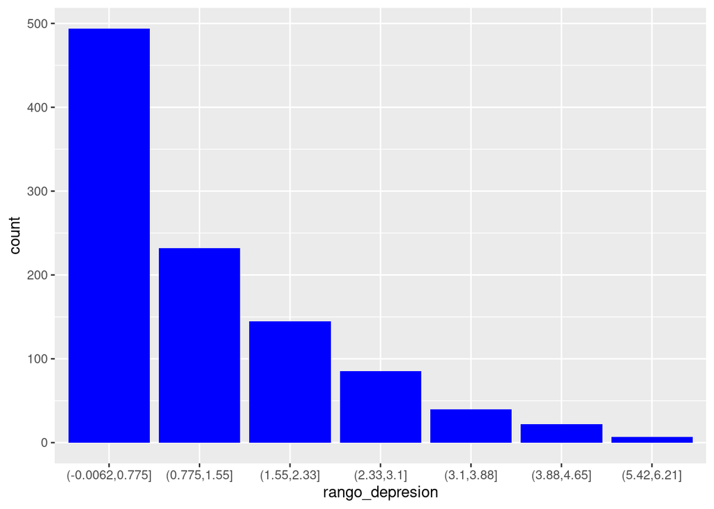

```r
heart_reducida |>
  ggplot(aes( rango_depresion)) +
  geom_bar(fill = "blue")
```

```r
heart |> descr(oldpeak)
```

```
## Descriptive Statistics
## heart$oldpeak
## N: 1025
##
##                     oldpeak
## ----------------- ---------
##              Mean      1.07
##           Std.Dev      1.18
##               Min      0.00
##                Q1      0.00
##            Median      0.80
##                Q3      1.80
##               Max      6.20
##               MAD      1.19
##               IQR      1.80
##                CV      1.10
##          Skewness      1.21
##       SE.Skewness      0.08
##          Kurtosis      1.29
##           N.Valid   1025.00
##         Pct.Valid    100.00
```

Podemos ver que muy pocos pacientes tienen irregularidades en el corazón, estando la mayoría de irregularidades en torno a 0-2,33.

#### Sexo

Gráfico de barras del sexo:

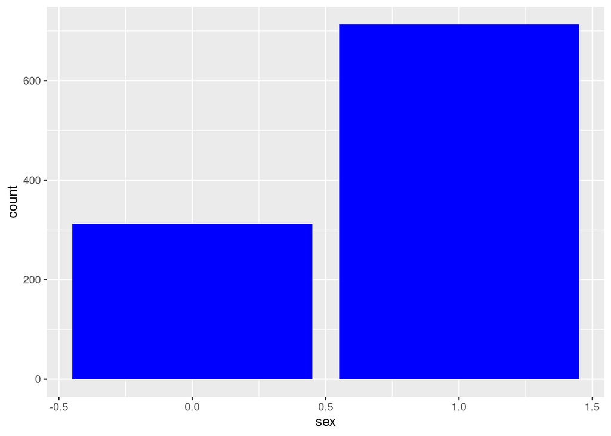

```r
heart_reducida |>
  ggplot(aes(sex )) +
  geom_bar(fill = "blue")
```

#### Edad

Gráfico de barras de la edad:

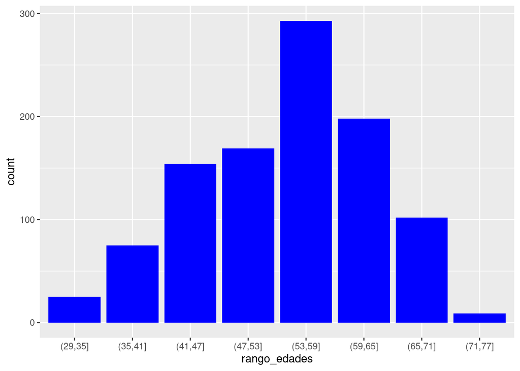

```r
heart_reducida |>
  ggplot(aes(rango_edades)) +
  geom_bar(fill = "blue")
```

```r
heart |> descr(age)
```

```
## Descriptive Statistics
## heart$age
## N: 1025
##
##                         age
## ----------------- ---------
##              Mean     54.43
##           Std.Dev      9.07
##               Min     29.00
##                Q1     48.00
##            Median     56.00
##                Q3     61.00
##               Max     77.00
##               MAD      8.90
##               IQR     13.00
##                CV      0.17
##          Skewness     -0.25
##       SE.Skewness      0.08
##          Kurtosis     -0.53
##           N.Valid   1025.00
##         Pct.Valid    100.00
```

La mayoría de las personas entrevistadas se encuentran entre un rango de edad de 53 y 59 años con una diferencia visible al número de personas entre 29 y 53 , y 59 y 77.

#### Nivel de azúcar en sangre en ayunas

Gráfico de barras del nivel de azúcar en sangre en ayunas:

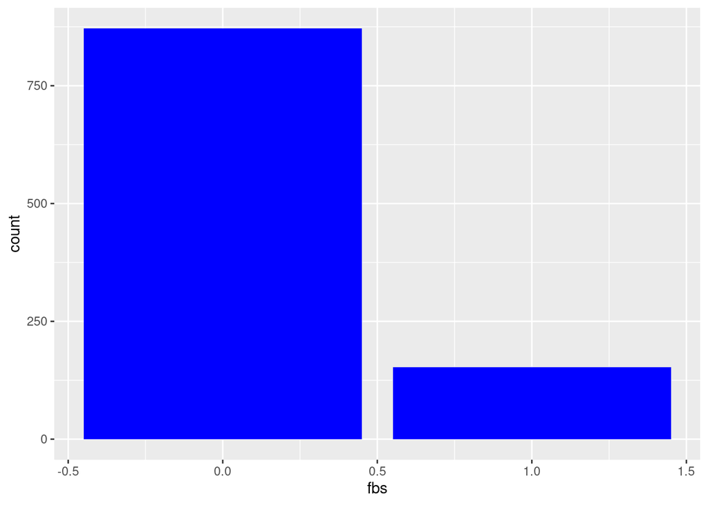

```r
heart_reducida |>
  ggplot(aes(fbs)) +
  geom_bar(fill = "blue")
```

La mayoría de las personas analizadas presentan un azúcar en sangre menor o igual a 120 mL/dL, mientras que unas pocas sufren de algún tipo de diabetes causando esto problemas cardiacos.

#### Resultados electrocardiográficos en reposo

Gráfico de barras de los resultados electrocardiográficos en reposo:

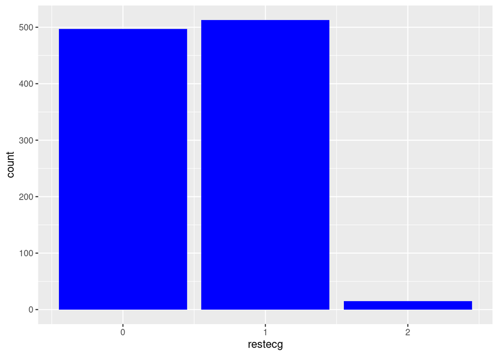

```r
heart_reducida |>
  ggplot(aes(restecg)) +
  geom_bar(fill = "blue")
```

La mayoría de las personas presentan una anomalía del corazón (distinta a hipertrofia). También una gran cantidad de personas (0) están sanas del corazón, mientras que una muy pequeña presenta hipertrofia del corazón.

#### Angina inducida por el ejercicio

Gráfico de barras de la angina inducida por el ejercicio:

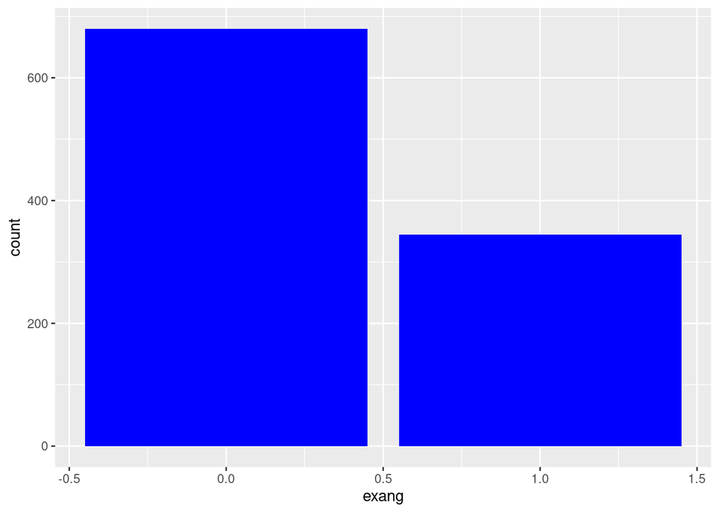

```r
heart_reducida |>
  ggplot(aes(exang)) +
  geom_bar(fill = "blue")
```

La mayoría de las personas no presentan anginas inducidas por ejercicio(0). Aunque una gran parte ha sufrido un problema del corazón debido a las anginas creadas por la realización de ejercicio.

#### Pendiente del segmento ST de ejercicio máximo

Gráfico de barras de la pendiente del segmento ST de ejercicio máximo:

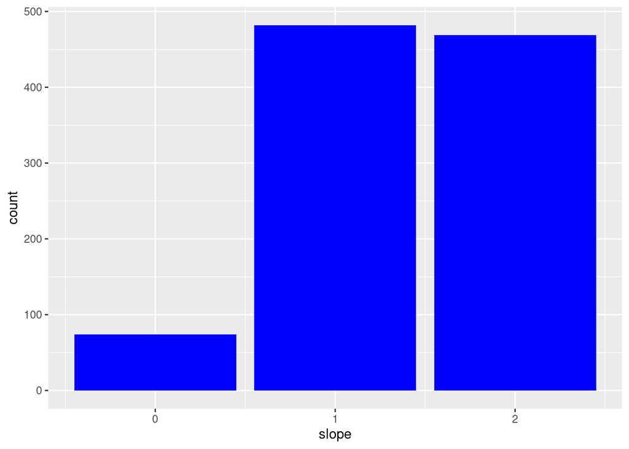

```r
heart_reducida |>
  ggplot(aes(slope)) +
  geom_bar(fill = "blue")
```

La mayoría de personas que han sufrido un infarto de corazón presentaban una pendiente del segmento ST de ejercicio máximo plana, aunque también una gran cantidad que haya sufrido un infarto presentaba una pendiente del segmento ST de ejercicio máximo descendente. Muy poca de las personas entrevistadas han sufrido infarto debido a una pendiente del segmento ST de ejercicio máximo ascendente.

#### Número de vasos principales coloreados por fluoroscopia

Gráfico de barras del número de vasos principales coloreados por fluoroscopia:

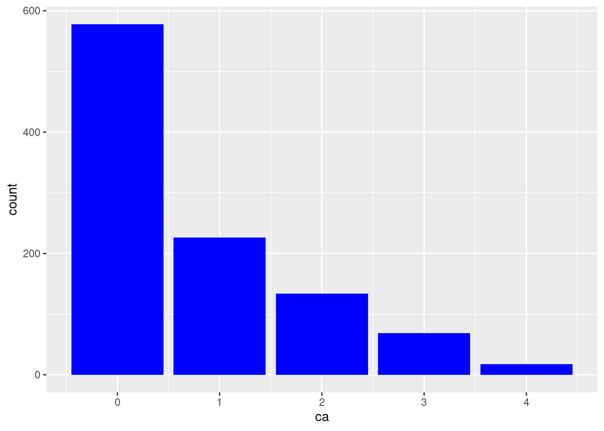

```r
heart_reducida |>
  ggplot(aes(ca)) +
  geom_bar(fill = "blue")
```

Hemos realizado una prueba que consiste en colorear los vasos sanguineos que nos determinan las enfermedades de corazón que buscamos. A la mayoría de las personas no se les ha coloreado ningun vaso sanguineo, mientras que a unos cuantos se les ha coloreado entre 1 y 3 vasos y a casi ningúna persona hemos coloreado un número de 4 vasos.

Gráfico de cajas del número de vasos principales coloreados por fluoroscopia:

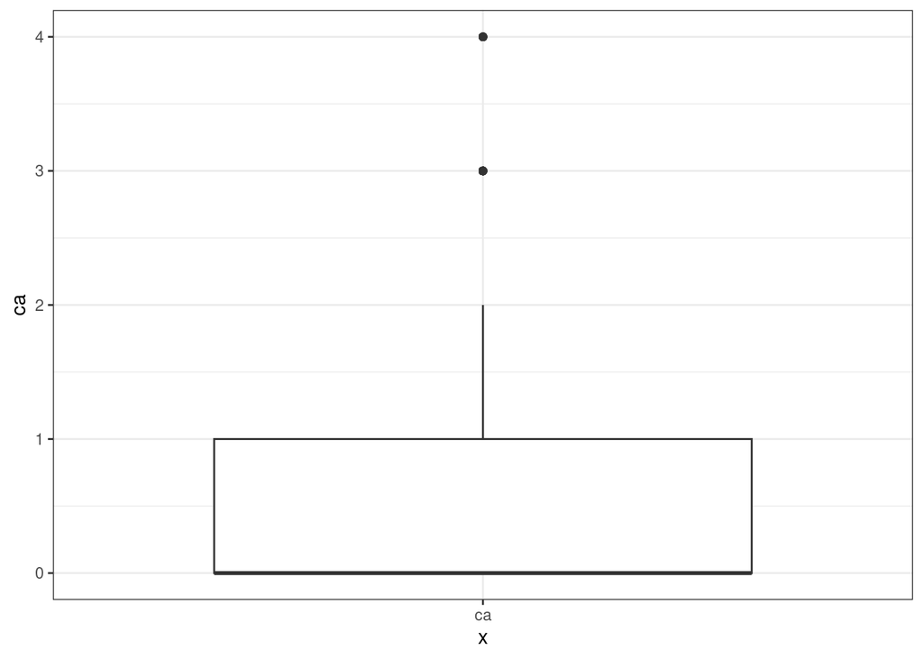

```r
heart_reducida |>
  ggplot(aes(x="ca", y =ca)) +
  geom_boxplot()+
  theme_bw()
```

A la mayoría de personas apenas se les ha realizado esta prueba mientras que a unas pocas personas se ha coloreado un número entre 2 y 4 venas.

#### Talasemia

Gráfico de barras de la talasemia:

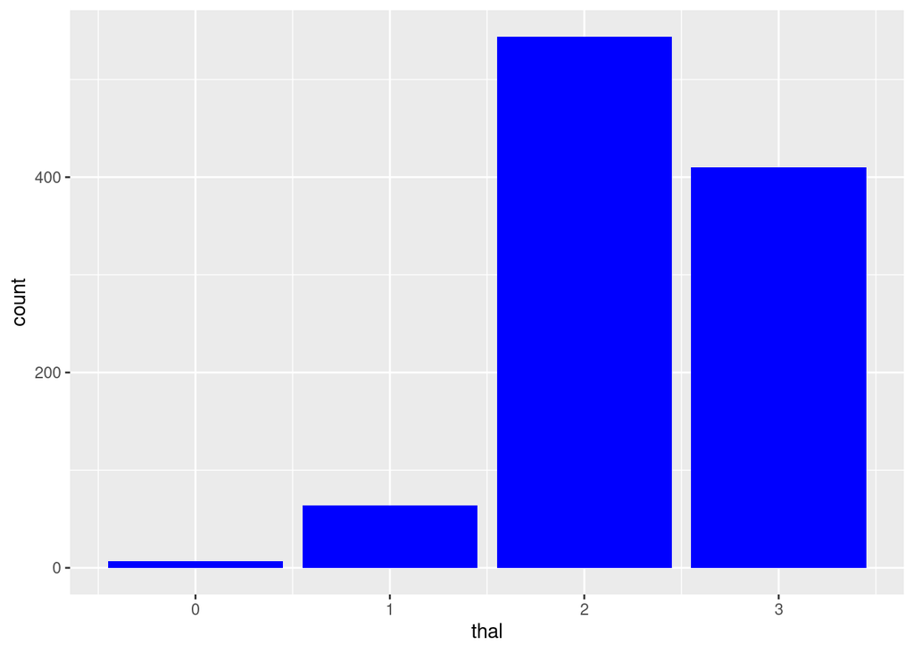

```r
heart_reducida |>
  ggplot(aes(thal)) +
  geom_bar(fill = "blue")
```

Una gran cantidad de personas presentan un anomalía en los niveles de hemoglobina de defecto fijo y reversible causado por la talasemia, mientras que muy poca gente presenta una número normal de celulas rojas en sangre.Esto significa que muchas de las personas presentan un problema de corazón causado por algún tipo de talasemia.

Gráfico de cajas de la talasemia:

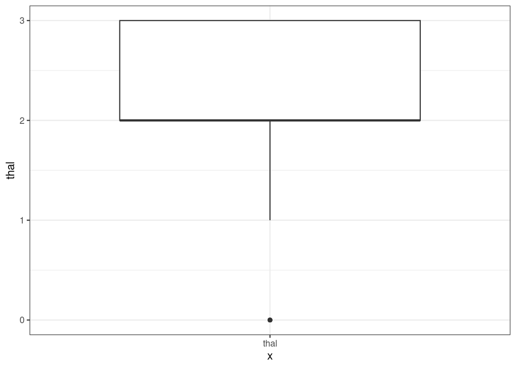

```r
heart_reducida |>
  ggplot(aes(x="thal", y =thal)) +
  geom_boxplot()+
  theme_bw()
```

Vemos que la mayoría de las personas presentan talasemia siendo esto la norma.

### Resúmenes numéricos

#### Comparativa edad-sexo:

```r
with(heart, stby(age, sex, descr))
```

```
## Descriptive Statistics
## age by sex
## Data Frame: heart
## N: 312
##
##                          0        1
## ----------------- -------- --------
##              Mean    55.85    53.81
##           Std.Dev     9.37     8.88
##               Min    34.00    29.00
##                Q1    50.00    47.00
##            Median    57.00    55.00
##                Q3    63.00    60.00
##               Max    76.00    77.00
##               MAD     8.90     8.90
##               IQR    13.00    13.00
##                CV     0.17     0.16
##          Skewness    -0.33    -0.24
##       SE.Skewness     0.14     0.09
##          Kurtosis    -0.59    -0.50
##           N.Valid   312.00   713.00
##         Pct.Valid   100.00   100.00
```

Podemos observar que la media de la edad a la que las mujeres sufren un ataque cardiaco es mayor que la de los hombres.

#### Comparativa colesterol-sexo:

```r
with(heart, stby(chol, sex, descr))
```

```
## Descriptive Statistics
## chol by sex
## Data Frame: heart
## N: 312
##
##                          0        1
## ----------------- -------- --------
##              Mean   261.46   239.24
##           Std.Dev    64.47    43.16
##               Min   141.00   126.00
##                Q1   215.00   208.00
##            Median   254.00   234.00
##                Q3   302.00   269.00
##               Max   564.00   353.00
##               MAD    60.05    43.00
##               IQR    87.00    61.00
##                CV     0.25     0.18
##          Skewness     1.27     0.19
##       SE.Skewness     0.14     0.09
##          Kurtosis     3.58    -0.34
##           N.Valid   312.00   713.00
##         Pct.Valid   100.00   100.00
```

También se puede ver que la media del colesterol es mayor en mujeres que en hombres, esto podría indicar que las mujeres son más propensas a sufrir un ataque cardiaco cuando su colesterol está muy alto.

#### Comparativa frecuencia cardíaca máxima-angina inducida por el ejercicio:

```r
with(heart, stby(thalach, exang, descr))
```

```
## Descriptive Statistics
## thalach by exang
## Data Frame: heart
## N: 680
##
##                          0        1
## ----------------- -------- --------
##              Mean   155.34   136.84
##           Std.Dev    21.51    20.83
##               Min    71.00    88.00
##                Q1   145.00   122.00
##            Median   159.50   138.00
##                Q3   170.50   152.00
##               Max   202.00   186.00
##               MAD    18.53    20.76
##               IQR    25.25    30.00
##                CV     0.14     0.15
##          Skewness    -0.95     0.04
##       SE.Skewness     0.09     0.13
##          Kurtosis     1.24    -0.47
##           N.Valid   680.00   345.00
##         Pct.Valid   100.00   100.00
```

La media de la frecuencia cardiaca máxima es mayor en las personas que no presentan angina inducida por el ejercicio, esto puede ser indicativo de que aquellas personas que sufren angina inducida por el ejercicio es debido a que su frecuencia cardiaca no es suficiente para que el oxígeno llegue bien al corazón y puedan llegar a sufrir un ataque cardiaco.

## Datos bivariantes

En el análisis bivariante compararemos la edad y el sexo con el resto de variables para ver si hay algún tipo de relación entre las condiciones médicas y la edad y sexo del paciente.

### Edad

#### Edad-Colesterol

Tabla comparativa:

```r
tabla_comparativa_edad_colesterol <- heart |>
  mutate(rango_edades = cut(age,breaks =8),
         rango_colesterol=cut(chol,breaks=8)) |>
  count(rango_edades,
        rango_colesterol)
kable(tabla_comparativa_edad_colesterol)
```

| rango_edades | rango_colesterol | n |
| --- | --- | --- |
| (29,35] | (181,236] | 22 |
| (29,35] | (236,290] | 3 |
| (35,41] | (126,181] | 19 |
| (35,41] | (181,236] | 41 |
| (35,41] | (236,290] | 9 |
| (35,41] | (290,345] | 6 |
| (41,47] | (126,181] | 21 |
| (41,47] | (181,236] | 51 |
| (41,47] | (236,290] | 55 |
| (41,47] | (290,345] | 27 |
| (47,53] | (126,181] | 7 |
| (47,53] | (181,236] | 84 |
| (47,53] | (236,290] | 56 |
| (47,53] | (290,345] | 22 |
| (53,59] | (126,181] | 16 |
| (53,59] | (181,236] | 102 |
| (53,59] | (236,290] | 122 |
| (53,59] | (290,345] | 43 |
| (53,59] | (345,400] | 7 |
| (53,59] | (400,454] | 3 |
| (59,65] | (126,181] | 13 |
| (59,65] | (181,236] | 60 |
| (59,65] | (236,290] | 73 |
| (59,65] | (290,345] | 39 |
| (59,65] | (345,400] | 6 |
| (59,65] | (400,454] | 7 |
| (65,71] | (126,181] | 8 |
| (65,71] | (181,236] | 35 |
| (65,71] | (236,290] | 43 |
| (65,71] | (290,345] | 13 |
| (65,71] | (509,564] | 3 |
| (71,77] | (181,236] | 3 |
| (71,77] | (236,290] | 3 |
| (71,77] | (290,345] | 3 |

Covarianza:

```r
cov_edad_colesterol <- cov(heart$age, heart$chol)
cov_edad_colesterol
```

```
## [1] 102.8906
```

Correlación:

```r
cor_edad_chol <- cor(heart$age, heart$chol)
cor_edad_chol
```

```
## [1] 0.2198225
```

El valor de la correlación, es positivo, lo que indica que a medida que una de las variables aumenta también lo hace la otra, aunque no se incrementa mucho ya que su relación no es muy fuerte (es cercana al 0, siendo el 1 una relación perfecta).

Gráfica de dispersión:

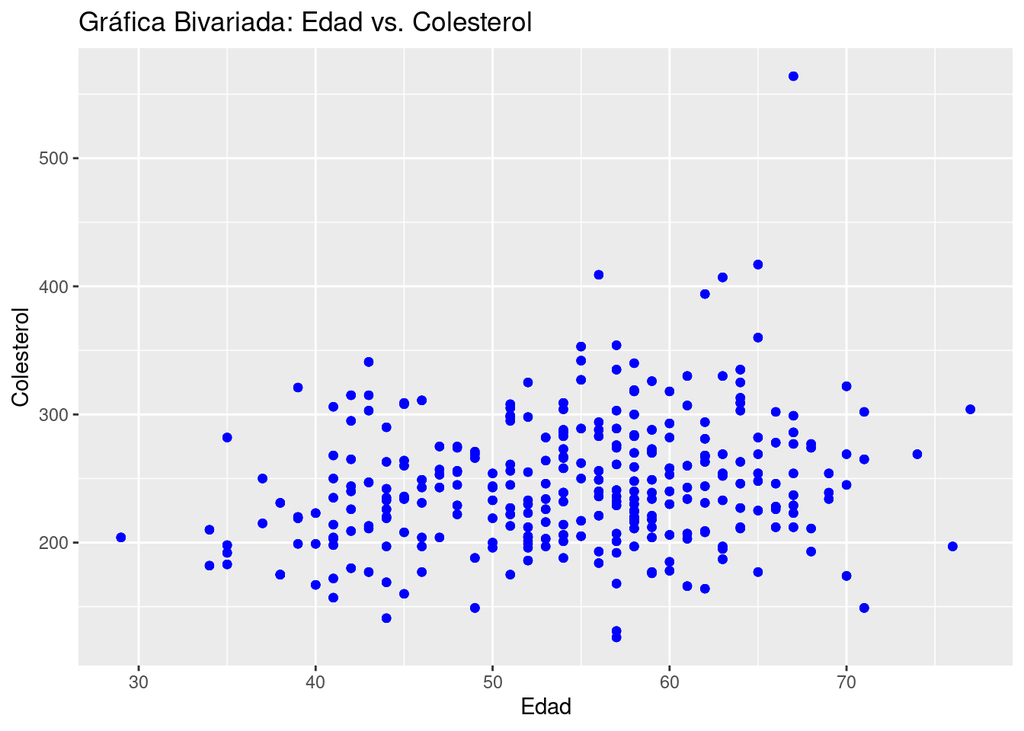

```r
ggplot(heart, aes(x = age, y = chol, color = factor(sex))) +
  geom_point(color = "blue") +
  labs(x = "Edad", y = "Colesterol") +
  ggtitle("Gráfica Bivariada: Edad vs. Colesterol") +
  scale_color_discrete(name = "Sexo")
```

Regresión lineal:

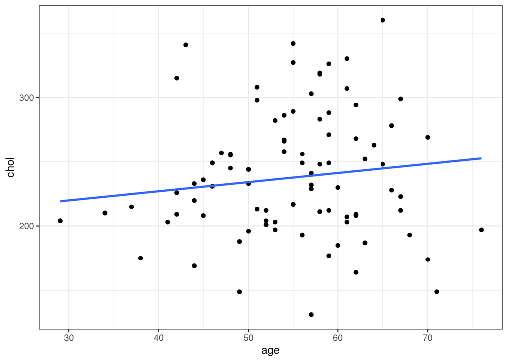

```r
heart |>
  slice(1:100) |>
  select(age, chol) |>
  ggplot(aes(x=age, y = chol)) +
  geom_point() +
  theme_bw() +
  geom_smooth(method = lm, se = FALSE)
```

```r
reg_edad_chol <- lm(chol ~ age, data = heart)
summary(reg_edad_chol)
```

```
##
## Call:
## lm(formula = chol ~ age, data = heart)
##
## Residuals:
##      Min       1Q   Median       3Q      Max
## -123.208  -32.707   -6.457   29.042  302.292
##
## Coefficients:
##             Estimate Std. Error t value Pr(>|t|)
## (Intercept) 177.9523     9.5718  18.591  < 2e-16 ***
## age           1.2501     0.1735   7.207 1.11e-12 ***
## ---
## Signif. codes:  0 '***' 0.001 '**' 0.01 '*' 0.05 '.' 0.1 ' ' 1
##
## Residual standard error: 50.36 on 1023 degrees of freedom
## Multiple R-squared:  0.04832,    Adjusted R-squared:  0.04739
## F-statistic: 51.94 on 1 and 1023 DF,  p-value: 1.108e-12
```

El error estándar es de 50,36, el coeficiente de determinación, R^2, es de 4.832%, un valor bajo, lo que indica que no hay mucha variación (el r ajustado posee un valor similar), y f-statistic, de 51,94 y 1023 grados de libertad indica que la edad tiene un impacto en el valor del colesterol (dado que hay una significancia estadística global alta).

#### Edad-Presión arterial en reposo

Tabla comparativa:

```r
tabla_comparativa_edad_presion_arterial <- heart |>
  mutate(rango_edades = cut(age,breaks =8),
         rango_presion_arterial=cut(trestbps,breaks=8)) |>
  count(rango_edades,
        rango_presion_arterial)
kable(tabla_comparativa_edad_presion_arterial)
```

| rango_edades | rango_presion_arterial | n |
| --- | --- | --- |
| (29,35] | (107,120] | 10 |
| (29,35] | (120,134] | 11 |
| (29,35] | (134,147] | 4 |
| (35,41] | (93.9,107] | 6 |
| (35,41] | (107,120] | 31 |
| (35,41] | (120,134] | 12 |
| (35,41] | (134,147] | 22 |
| (35,41] | (147,160] | 4 |
| (41,47] | (93.9,107] | 12 |
| (41,47] | (107,120] | 70 |
| (41,47] | (120,134] | 34 |
| (41,47] | (134,147] | 29 |
| (41,47] | (147,160] | 9 |
| (47,53] | (93.9,107] | 8 |
| (47,53] | (107,120] | 41 |
| (47,53] | (120,134] | 70 |
| (47,53] | (134,147] | 41 |
| (47,53] | (147,160] | 6 |
| (47,53] | (160,174] | 3 |
| (53,59] | (93.9,107] | 10 |
| (53,59] | (107,120] | 62 |
| (53,59] | (120,134] | 93 |
| (53,59] | (134,147] | 54 |
| (53,59] | (147,160] | 39 |
| (53,59] | (160,174] | 18 |
| (53,59] | (174,187] | 10 |
| (53,59] | (187,200] | 7 |
| (59,65] | (93.9,107] | 3 |
| (59,65] | (107,120] | 35 |
| (59,65] | (120,134] | 49 |
| (59,65] | (134,147] | 70 |
| (59,65] | (147,160] | 34 |
| (59,65] | (160,174] | 4 |
| (59,65] | (174,187] | 3 |
| (65,71] | (93.9,107] | 6 |
| (65,71] | (107,120] | 32 |
| (65,71] | (120,134] | 7 |
| (65,71] | (134,147] | 17 |
| (65,71] | (147,160] | 33 |
| (65,71] | (174,187] | 7 |
| (71,77] | (107,120] | 3 |
| (71,77] | (120,134] | 3 |
| (71,77] | (134,147] | 3 |

Covarianza:

```r
cov_edad_presion_arterial <- cov(heart$age, heart$trestbps)
cov_edad_presion_arterial
```

```
## [1] 43.08573
```

Esta covarianza, que es positiva, indica que conforme la edad aumenta también aumenta la presión arterial, aunque la relación con la que aumenta la calcularemos con la correlación.

Correlación:

```r
cor_edad_trestbps <- cor(heart$age, heart$trestbps)
cor_edad_trestbps
```

```
## [1] 0.2711214
```

El valor de la correlación es positivo, lo que indica que a medida que una de las variables aumenta también lo hace la otra, aunque no se incrementa mucho ya que su relación no es muy fuerte (es cercana al 0, siendo el 1 una relación perfecta).

Gráfica de dispersión:

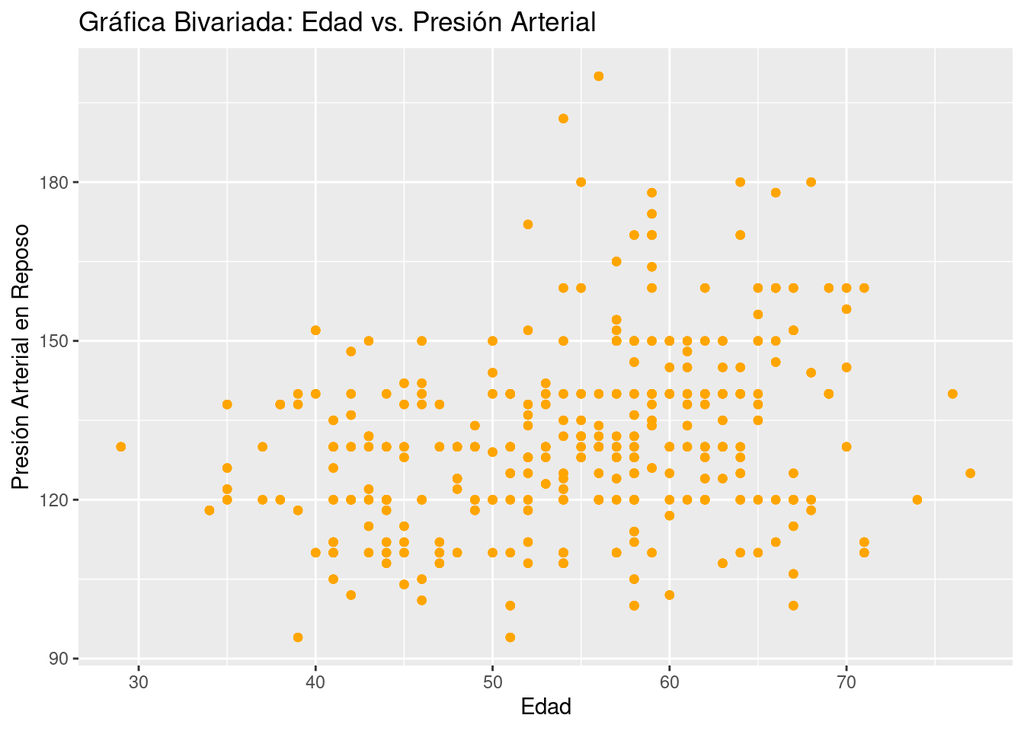

```r
ggplot(heart, aes(x = age, y = trestbps, color = factor(sex))) +
  geom_point(color = "orange") +
  labs(x = "Edad", y = "Presión Arterial en Reposo") +
  ggtitle("Gráfica Bivariada: Edad vs. Presión Arterial") +
  scale_color_discrete(name = "Sexo")
```

En esta gráfica los datos están más dispersos que en la de edad y colesterol, aunque la mayoría están en el intervalo 110-135, valores en los que la presión arterial es normal (valores cerca del 120, que es la presión idónea), aunque hay bastantes valores en los que la presión es ligeramente alta (hasta 140) o extremadamente alta (por encima de 140, tienen hipertensión). Los pacientes cuya tensión es menor que 100 tienen hipotensión.

Regresión lineal:

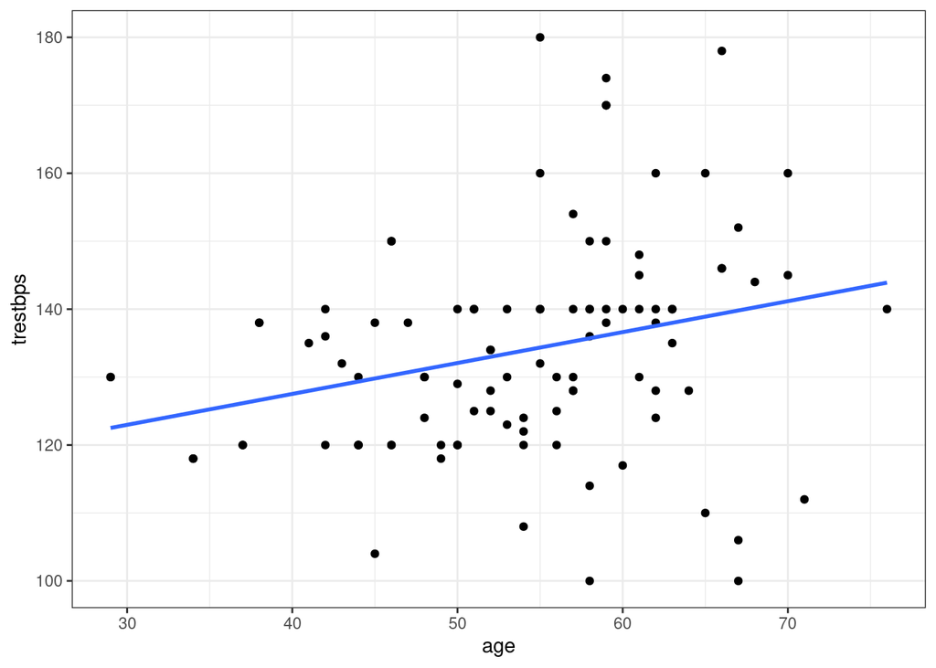

```r
heart |>
  slice(1:100) |>
  select(age, trestbps) |>
  ggplot(aes(x=age, y = trestbps)) +
  geom_point() +
  theme_bw() +
  geom_smooth(method = lm, se = FALSE)
```

```r
reg_edad_trestbps <- lm(trestbps ~ age, data = heart)
summary(reg_edad_trestbps)
```

```
##
## Call:
## lm(formula = trestbps ~ age, data = heart)
##
## Residuals:
##     Min      1Q  Median      3Q     Max
## -38.190 -11.384  -1.096  10.186  67.569
##
## Coefficients:
##              Estimate Std. Error t value Pr(>|t|)
## (Intercept) 103.11655    3.20652  32.158   <2e-16 ***
## age           0.52348    0.05811   9.009   <2e-16 ***
## ---
## Signif. codes:  0 '***' 0.001 '**' 0.01 '*' 0.05 '.' 0.1 ' ' 1
##
## Residual standard error: 16.87 on 1023 degrees of freedom
## Multiple R-squared:  0.07351,    Adjusted R-squared:  0.0726
## F-statistic: 81.16 on 1 and 1023 DF,  p-value: < 2.2e-16
```

#### Edad-Frecuancia cardiaca máxima

Tabla comparativa:

```r
tabla_comparativa_edad_frec_cardíaca_max <- heart |>
  mutate(rango_edades = cut(age,breaks =8),
         rango_frec_cardíaca_max=cut(thalach,breaks=8)) |>
  count(rango_edades,
        rango_frec_cardíaca_max)
kable(tabla_comparativa_edad_frec_cardíaca_max)
```

| rango_edades | rango_frec_cardíaca_max | n |
| --- | --- | --- |
| (29,35] | (120,136] | 4 |
| (29,35] | (153,169] | 3 |
| (29,35] | (169,186] | 11 |
| (29,35] | (186,202] | 7 |
| (35,41] | (104,120] | 4 |
| (35,41] | (120,136] | 4 |
| (35,41] | (136,153] | 8 |
| (35,41] | (153,169] | 15 |
| (35,41] | (169,186] | 41 |
| (35,41] | (186,202] | 3 |
| (41,47] | (104,120] | 12 |
| (41,47] | (120,136] | 14 |
| (41,47] | (136,153] | 43 |
| (41,47] | (153,169] | 28 |
| (41,47] | (169,186] | 51 |
| (41,47] | (186,202] | 6 |
| (47,53] | (87.4,104] | 4 |
| (47,53] | (104,120] | 6 |
| (47,53] | (120,136] | 19 |
| (47,53] | (136,153] | 33 |
| (47,53] | (153,169] | 72 |
| (47,53] | (169,186] | 25 |
| (47,53] | (186,202] | 10 |
| (53,59] | (87.4,104] | 10 |
| (53,59] | (104,120] | 39 |
| (53,59] | (120,136] | 46 |
| (53,59] | (136,153] | 65 |
| (53,59] | (153,169] | 101 |
| (53,59] | (169,186] | 29 |
| (53,59] | (186,202] | 3 |
| (59,65] | (87.4,104] | 18 |
| (59,65] | (104,120] | 10 |
| (59,65] | (120,136] | 32 |
| (59,65] | (136,153] | 60 |
| (59,65] | (153,169] | 60 |
| (59,65] | (169,186] | 18 |
| (65,71] | (70.9,87.4] | 4 |
| (65,71] | (104,120] | 20 |
| (65,71] | (120,136] | 26 |
| (65,71] | (136,153] | 36 |
| (65,71] | (153,169] | 13 |
| (65,71] | (169,186] | 3 |
| (71,77] | (104,120] | 3 |
| (71,77] | (120,136] | 3 |
| (71,77] | (153,169] | 3 |

Covarianza:

```r
cov_edad_frec_cardiaca <- cov(heart$age, heart$thalach)
cov_edad_frec_cardiaca
```

```
## [1] -81.44609
```

Esta covarianza, que es negativa, indica que conforme la edad aumenta disminuye la frecuencia cardíaca máxima, aunque la relación con la que disminuye la calcularemos con la correlación.

Correlación:

```r
cor_edad_thalach <- cor(heart$age, heart$thalach)
cor_edad_thalach
```

```
## [1] -0.3902271
```

El valor de la correlación es negativo, lo que indica que a medida que una de las variables aumenta la otra disminuye, aunque no decrece mucho ya que su relación no es muy fuerte (es cercana al 0, siendo el -1 una relación perfecta).

Gráfica de dispersión:

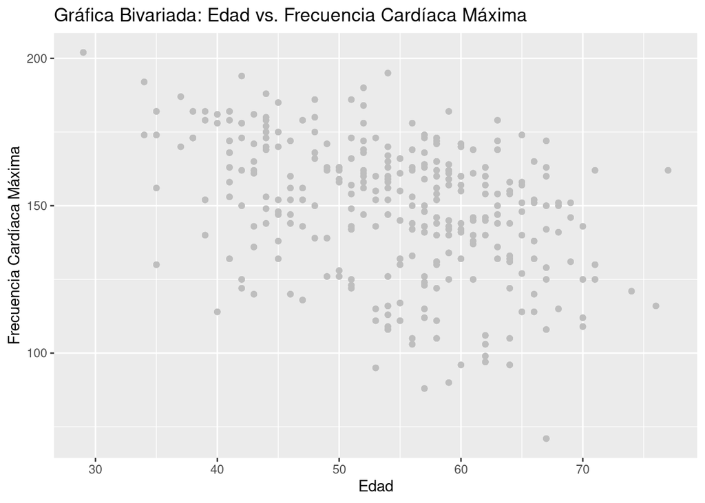

```r
ggplot(heart, aes(x = age, y = thalach)) +
  geom_point(color="grey") +
  labs(x = "Edad", y = "Frecuencia Cardíaca Máxima") +
  ggtitle("Gráfica Bivariada: Edad vs. Frecuencia Cardíaca Máxima")
```

Regresión lineal:

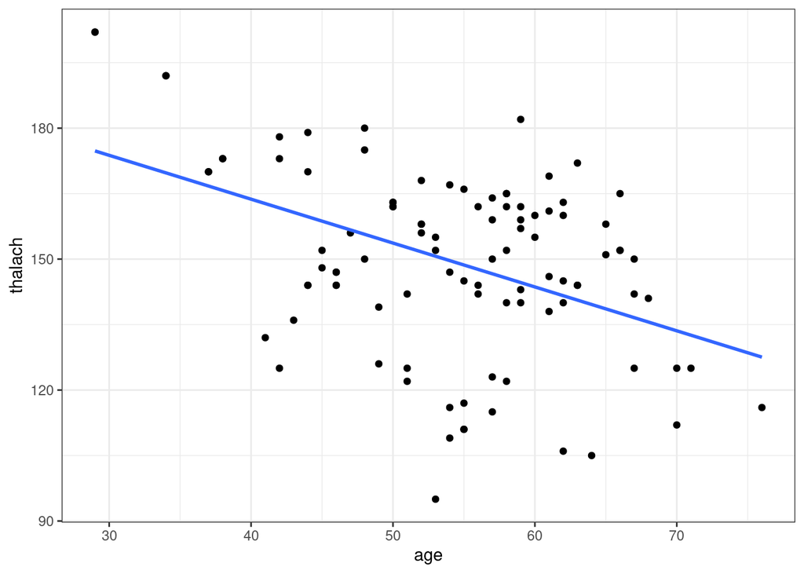

```r
heart |>
  slice(1:100) |>
  select(age, thalach) |>
  ggplot(aes(x=age, y = thalach)) +
  geom_point() +
  theme_bw() +
  geom_smooth(method = lm, se = FALSE)
```

```r
reg_edad_thalach <- lm(thalach ~ age, data = heart)
summary(reg_edad_thalach)
```

```
##
## Call:
## lm(formula = thalach ~ age, data = heart)
##
## Residuals:
##     Min      1Q  Median      3Q     Max
## -65.680 -11.680   4.373  16.394  45.456
##
## Coefficients:
##             Estimate Std. Error t value Pr(>|t|)
## (Intercept) 202.9793     4.0283   50.39   <2e-16 ***
## age          -0.9896     0.0730  -13.56   <2e-16 ***
## ---
## Signif. codes:  0 '***' 0.001 '**' 0.01 '*' 0.05 '.' 0.1 ' ' 1
##
## Residual standard error: 21.19 on 1023 degrees of freedom
## Multiple R-squared:  0.1523, Adjusted R-squared:  0.1514
## F-statistic: 183.8 on 1 and 1023 DF,  p-value: < 2.2e-16
```

#### Edad-Depresión ST

Tabla comparativa:

```r
tabla_comparativa_edad_depresion <- heart |>
  mutate(rango_edades = cut(age,breaks =8),
         rango_depresion=cut(oldpeak,breaks=8)) |>
  count(rango_edades,
        rango_depresion)
kable(tabla_comparativa_edad_depresion)
```

| rango_edades | rango_depresion | n |
| --- | --- | --- |
| (29,35] | (-0.0062,0.775] | 17 |
| (29,35] | (0.775,1.55] | 4 |
| (29,35] | (1.55,2.33] | 4 |
| (35,41] | (-0.0062,0.775] | 51 |
| (35,41] | (0.775,1.55] | 10 |
| (35,41] | (1.55,2.33] | 7 |
| (35,41] | (3.1,3.88] | 7 |
| (41,47] | (-0.0062,0.775] | 99 |
| (41,47] | (0.775,1.55] | 26 |
| (41,47] | (1.55,2.33] | 11 |
| (41,47] | (2.33,3.1] | 15 |
| (41,47] | (3.1,3.88] | 3 |
| (47,53] | (-0.0062,0.775] | 97 |
| (47,53] | (0.775,1.55] | 44 |
| (47,53] | (1.55,2.33] | 15 |
| (47,53] | (2.33,3.1] | 10 |
| (47,53] | (3.88,4.65] | 3 |
| (53,59] | (-0.0062,0.775] | 135 |
| (53,59] | (0.775,1.55] | 63 |
| (53,59] | (1.55,2.33] | 47 |
| (53,59] | (2.33,3.1] | 18 |
| (53,59] | (3.1,3.88] | 15 |
| (53,59] | (3.88,4.65] | 11 |
| (53,59] | (5.42,6.21] | 4 |
| (59,65] | (-0.0062,0.775] | 53 |
| (59,65] | (0.775,1.55] | 57 |
| (59,65] | (1.55,2.33] | 41 |
| (59,65] | (2.33,3.1] | 24 |
| (59,65] | (3.1,3.88] | 12 |
| (59,65] | (3.88,4.65] | 8 |
| (59,65] | (5.42,6.21] | 3 |
| (65,71] | (-0.0062,0.775] | 36 |
| (65,71] | (0.775,1.55] | 25 |
| (65,71] | (1.55,2.33] | 20 |
| (65,71] | (2.33,3.1] | 18 |
| (65,71] | (3.1,3.88] | 3 |
| (71,77] | (-0.0062,0.775] | 6 |
| (71,77] | (0.775,1.55] | 3 |

Covarianza:

```r
cov_edad_depresion <- cov(heart$age, heart$oldpeak)
cov_edad_depresion
```

```
## [1] 2.218825
```

Esta covarianza, que es positiva, indica que conforme la edad aumenta también aumenta la depresión, aunque la relación con la que aumenta la calcularemos con la correlación.

Correlación:

```r
cor_edad_oldpeak <- cor(heart$age, heart$oldpeak)
cor_edad_oldpeak
```

```
## [1] 0.2081367
```

El valor de la correlación es positivo, lo que indica que a medida que una de las variables aumenta también lo hace la otra, aunque no se incrementa mucho ya que su relación no es muy fuerte (es cercana al 0, siendo el 1 una relación perfecta).

Gráfica de dispersión:

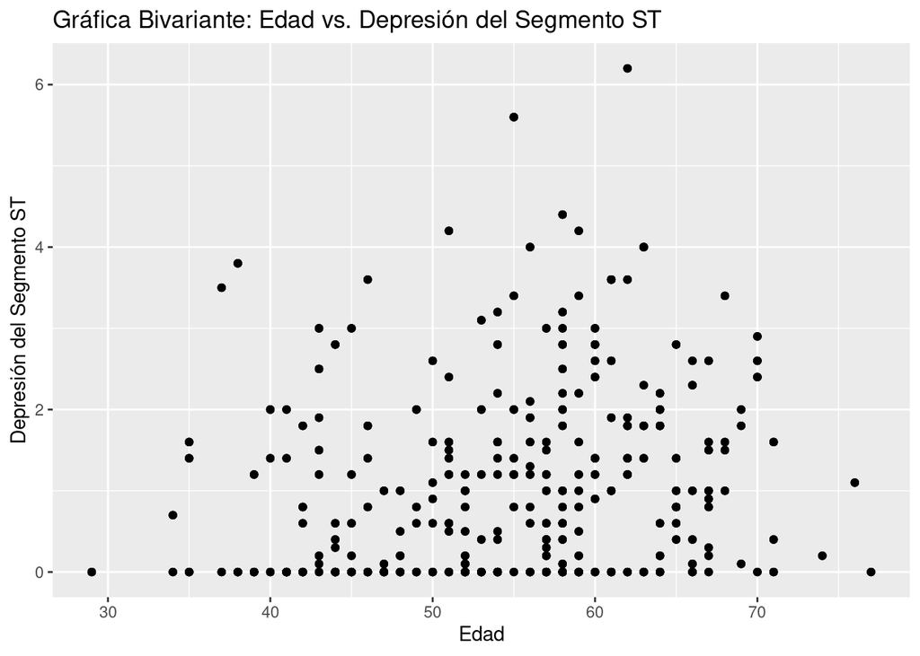

```r
ggplot(heart, aes(x = age, y = oldpeak)) +
  geom_point(color="black") +
  labs(x = "Edad", y = "Depresión del Segmento ST") +
  ggtitle("Gráfica Bivariante: Edad vs. Depresión del Segmento ST")
```

La depresión, las irregularidades en el corazón, su valor normal es de 0. Como se puede ver en la gráfica, muchos pacientes tienen cero irregularidades. Otros en cambio, parecen tener una ligera arritmia (entre 0 y 4), mientras que los 5 pacientes que superan el 4 tienen irregularidades muy severas. No obstante, como la regresión ha demostrado, las irregularidades apenas aumentan con la edad.

Regresión lineal:

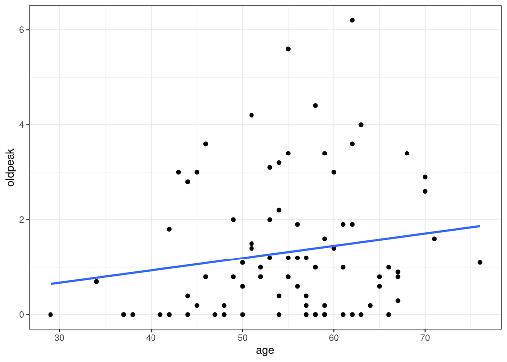

```r
heart |>
  slice(1:100) |>
  select(age, oldpeak) |>
  ggplot(aes(x=age, y = oldpeak)) +
  geom_point() +
  theme_bw() +
  geom_smooth(method = lm, se = FALSE)
```

```r
reg_edad_oldpeak <- lm(oldpeak ~ age, data = heart)
summary(reg_edad_oldpeak)
```

```
##
## Call:
## lm(formula = oldpeak ~ age, data = heart)
##
## Residuals:
##     Min      1Q  Median      3Q     Max
## -1.6798 -0.8441 -0.3563  0.6211  4.9245
##
## Coefficients:
##              Estimate Std. Error t value Pr(>|t|)
## (Intercept) -0.395929   0.218575  -1.811   0.0704 .
## age          0.026958   0.003961   6.806  1.7e-11 ***
## ---
## Signif. codes:  0 '***' 0.001 '**' 0.01 '*' 0.05 '.' 0.1 ' ' 1
##
## Residual standard error: 1.15 on 1023 degrees of freedom
## Multiple R-squared:  0.04332,    Adjusted R-squared:  0.04239
## F-statistic: 46.32 on 1 and 1023 DF,  p-value: 1.705e-11
```

El error estándar es de 1,15 (un error bajo comparado con el resto de errores), el coeficiente de determinación, R^2, es de 4,332%, un valor bajo, lo que indica que no hay mucha variación (el r ajustado posee un valor similar), y f-statistic, de 46,32 y 1023 grados de libertad indica que la edad tiene un impacto en el valor de la depresión (dado que hay una significancia estadística global alta, aunque menor que en otras variables).

#### Edad-Porcentaje de riesgo de ataque al corazón

Tabla comparativa:

```r
tabla_comparativa_edad_target <- heart |>
  mutate(rango_edades = cut(age,breaks =8),
         rango_target=cut(target,breaks=8)) |>
  count(rango_edades,
        rango_target)
kable(tabla_comparativa_edad_target)
```

| rango_edades | rango_target | n |
| --- | --- | --- |
| (29,35] | (0.2,0.3] | 6 |
| (29,35] | (0.3,0.4] | 1 |
| (29,35] | (0.7,0.8] | 8 |
| (29,35] | (0.8,0.901] | 10 |
| (35,41] | (0.0992,0.2] | 7 |
| (35,41] | (0.2,0.3] | 8 |
| (35,41] | (0.3,0.4] | 4 |
| (35,41] | (0.6,0.7] | 2 |
| (35,41] | (0.7,0.8] | 28 |
| (35,41] | (0.8,0.901] | 26 |
| (41,47] | (0.0992,0.2] | 13 |
| (41,47] | (0.2,0.3] | 18 |
| (41,47] | (0.3,0.4] | 19 |
| (41,47] | (0.6,0.7] | 2 |
| (41,47] | (0.7,0.8] | 53 |
| (41,47] | (0.8,0.901] | 49 |
| (47,53] | (0.0992,0.2] | 21 |
| (47,53] | (0.2,0.3] | 19 |
| (47,53] | (0.3,0.4] | 21 |
| (47,53] | (0.6,0.7] | 2 |
| (47,53] | (0.7,0.8] | 58 |
| (47,53] | (0.8,0.901] | 48 |
| (53,59] | (0.0992,0.2] | 72 |
| (53,59] | (0.2,0.3] | 53 |
| (53,59] | (0.3,0.4] | 49 |
| (53,59] | (0.6,0.7] | 2 |
| (53,59] | (0.7,0.8] | 51 |
| (53,59] | (0.8,0.901] | 66 |
| (59,65] | (0.0992,0.2] | 43 |
| (59,65] | (0.2,0.3] | 43 |
| (59,65] | (0.3,0.4] | 46 |
| (59,65] | (0.6,0.7] | 2 |
| (59,65] | (0.7,0.8] | 24 |
| (59,65] | (0.8,0.901] | 40 |
| (65,71] | (0.0992,0.2] | 14 |
| (65,71] | (0.2,0.3] | 17 |
| (65,71] | (0.3,0.4] | 22 |
| (65,71] | (0.6,0.7] | 1 |
| (65,71] | (0.7,0.8] | 20 |
| (65,71] | (0.8,0.901] | 28 |
| (71,77] | (0.0992,0.2] | 2 |
| (71,77] | (0.3,0.4] | 1 |
| (71,77] | (0.7,0.8] | 3 |
| (71,77] | (0.8,0.901] | 3 |

Covarianza:

```r
cov_edad_target <- cov(heart$age, heart$target)
cov_edad_target
```

```
## [1] -0.5598571
```

Correlación:

```r
cor_edad_target <- cor(heart$age, heart$target)
cor_edad_target
```

```
## [1] -0.2159057
```

El valor de la correlación es negativo, lo que indica que a medida que una de las variables aumenta la otra disminuye, aunque no decrece mucho ya que su relación no es muy fuerte (es cercana al 0, siendo el -1 una relación perfecta).

Gráfica de dispersión:

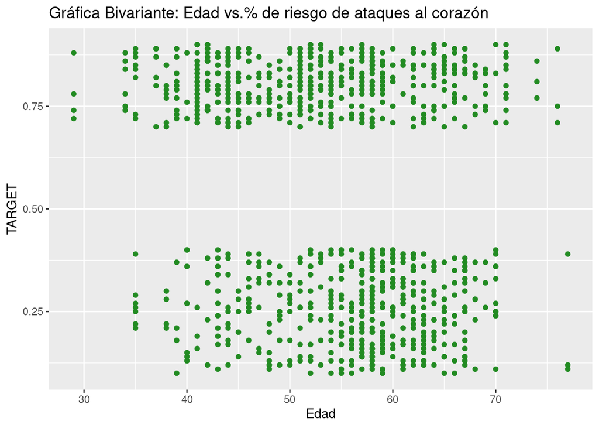

```r
ggplot(heart, aes(x = age, y = target)) +
  geom_point(color="forestgreen") +
  labs(x = "Edad", y = "TARGET") +
  ggtitle("Gráfica Bivariante: Edad vs.% de riesgo de ataques al corazón")
```

Esta gráfica es muy interesante, ya que hay un claro intervalo (40-60, aproximadamente) en los que no hay ni un solo dato. Este vacío representa la diferencia entre un riesgo de ataques al corazón relativamente bajo (la franja de datos inferior) y uno alto (la franja de datos superior).

Regresión lineal:

```r
reg_edad_target <- lm(target ~ age, data = heart)
summary(reg_edad_target)
```

```
##
## Call:
## lm(formula = target ~ age, data = heart)
##
## Residuals:
##      Min       1Q   Median       3Q      Max
## -0.54137 -0.26736  0.08543  0.25426  0.50030
##
## Coefficients:
##               Estimate Std. Error t value Pr(>|t|)
## (Intercept)  0.9066570  0.0530751  17.083  < 2e-16 ***
## age         -0.0068021  0.0009618  -7.072 2.82e-12 ***
## ---
## Signif. codes:  0 '***' 0.001 '**' 0.01 '*' 0.05 '.' 0.1 ' ' 1
##
## Residual standard error: 0.2792 on 1023 degrees of freedom
## Multiple R-squared:  0.04662,    Adjusted R-squared:  0.04568
## F-statistic: 50.02 on 1 and 1023 DF,  p-value: 2.819e-12
```

#### Edad-Tipo de dolor en el pecho

Tabla comparativa:

```r
tabla_comparativa_edad_cp <- heart |>
  mutate(rango_edades = cut(age,breaks =8)) |>
  count(rango_edades,cp)
kable(tabla_comparativa_edad_cp)
```

| rango_edades | cp | n |
| --- | --- | --- |
| (29,35] | 0 | 11 |
| (29,35] | 1 | 11 |
| (29,35] | 3 | 3 |
| (35,41] | 0 | 15 |
| (35,41] | 1 | 20 |
| (35,41] | 2 | 33 |
| (35,41] | 3 | 7 |
| (41,47] | 0 | 70 |
| (41,47] | 1 | 29 |
| (41,47] | 2 | 49 |
| (41,47] | 3 | 6 |
| (47,53] | 0 | 70 |
| (47,53] | 1 | 25 |
| (47,53] | 2 | 64 |
| (47,53] | 3 | 10 |
| (53,59] | 0 | 153 |
| (53,59] | 1 | 60 |
| (53,59] | 2 | 60 |
| (53,59] | 3 | 20 |
| (59,65] | 0 | 124 |
| (59,65] | 1 | 10 |
| (59,65] | 2 | 42 |
| (59,65] | 3 | 22 |
| (65,71] | 0 | 51 |
| (65,71] | 1 | 9 |
| (65,71] | 2 | 33 |
| (65,71] | 3 | 9 |
| (71,77] | 0 | 3 |
| (71,77] | 1 | 3 |
| (71,77] | 2 | 3 |

Gráfico de barras:

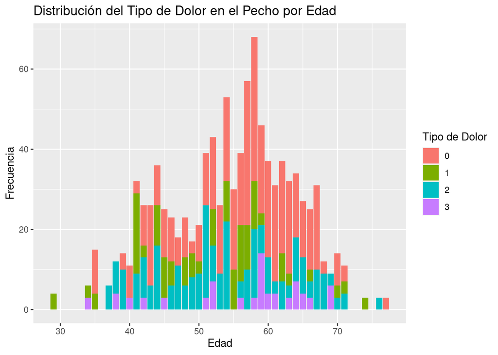

```r
ggplot(heart, aes(x = age, fill = factor(cp))) +
  geom_bar() +
  labs(x = "Edad", y = "Frecuencia", fill = "Tipo de Dolor") +
  ggtitle("Distribución del Tipo de Dolor en el Pecho por Edad")
```

#### Edad-Azúcar en sangre en ayunas

Tabla comparativa:

```r
tabla_comparativa_edad_fbs <- heart |>
  mutate(rango_edades = cut(age,breaks =8)) |>
  count(rango_edades,fbs)
kable(tabla_comparativa_edad_fbs)
```

| rango_edades | fbs | n |
| --- | --- | --- |
| (29,35] | 0 | 25 |
| (35,41] | 0 | 75 |
| (41,47] | 0 | 141 |
| (41,47] | 1 | 13 |
| (47,53] | 0 | 133 |
| (47,53] | 1 | 36 |
| (53,59] | 0 | 239 |
| (53,59] | 1 | 54 |
| (59,65] | 0 | 168 |
| (59,65] | 1 | 30 |
| (65,71] | 0 | 82 |
| (65,71] | 1 | 20 |
| (71,77] | 0 | 9 |

Gráfico de barras:

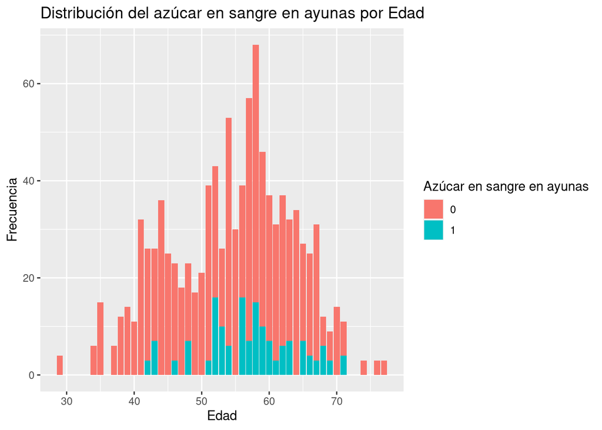

```r
ggplot(heart, aes(x = age, fill = factor(fbs))) +
  geom_bar() +
  labs(x = "Edad", y = "Frecuencia", fill = "Azúcar en sangre en ayunas") +
  ggtitle("Distribución del azúcar en sangre en ayunas por Edad")
```

#### Edad-Resultados electrocardiográficos en reposo

Tabla comparativa:

```r
tabla_comparativa_edad_restecg <- heart |>
  mutate(rango_edades = cut(age,breaks =8)) |>
  count(rango_edades,restecg)
kable(tabla_comparativa_edad_restecg)
```

| rango_edades | restecg | n |
| --- | --- | --- |
| (29,35] | 0 | 10 |
| (29,35] | 1 | 15 |
| (35,41] | 0 | 19 |
| (35,41] | 1 | 56 |
| (41,47] | 0 | 65 |
| (41,47] | 1 | 89 |
| (47,53] | 0 | 73 |
| (47,53] | 1 | 96 |
| (53,59] | 0 | 158 |
| (53,59] | 1 | 123 |
| (53,59] | 2 | 12 |
| (59,65] | 0 | 110 |
| (59,65] | 1 | 88 |
| (65,71] | 0 | 56 |
| (65,71] | 1 | 46 |
| (71,77] | 0 | 6 |
| (71,77] | 2 | 3 |

Gráfico de barras:

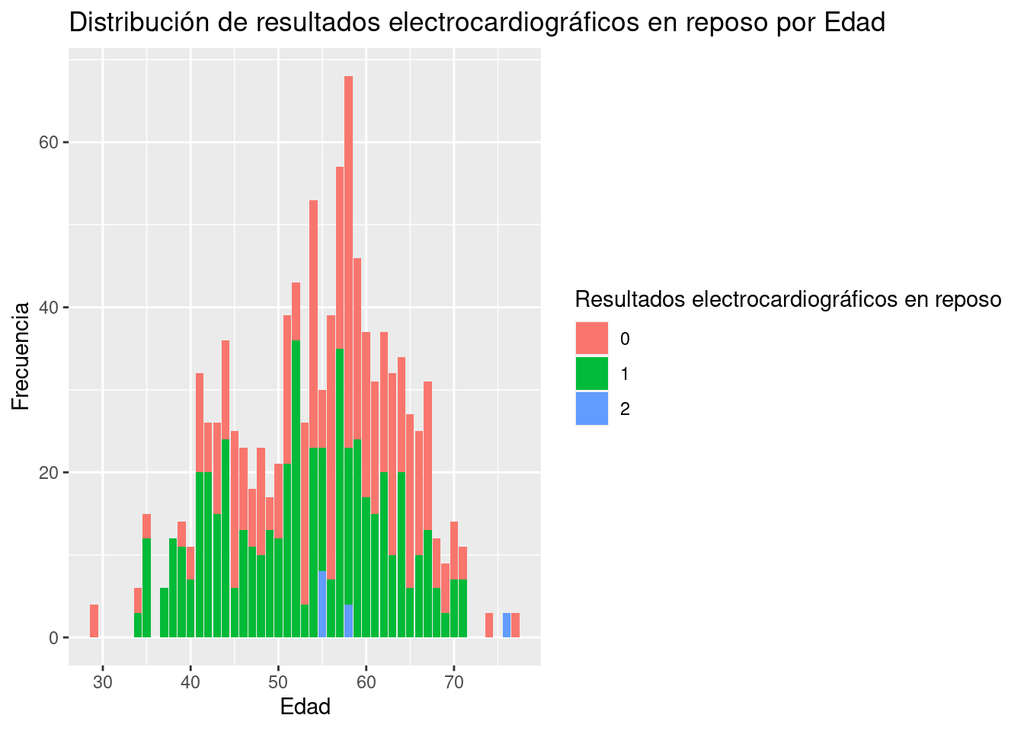

```r
ggplot(heart, aes(x = age, fill = factor(restecg))) +
  geom_bar() +
  labs(x = "Edad", y = "Frecuencia", fill = "Resultados electrocardiográficos en reposo") +
  ggtitle("Distribución de resultados electrocardiográficos en reposo por Edad")
```

#### Edad-Angina inducida por el ejercicio

Tabla comparativa:

```r
tabla_comparativa_edad_exang <- heart |>
  mutate(rango_edades = cut(age,breaks =8)) |>
  count(rango_edades,exang)
kable(tabla_comparativa_edad_exang)
```

| rango_edades | exang | n |
| --- | --- | --- |
| (29,35] | 0 | 18 |
| (29,35] | 1 | 7 |
| (35,41] | 0 | 61 |
| (35,41] | 1 | 14 |
| (41,47] | 0 | 109 |
| (41,47] | 1 | 45 |
| (47,53] | 0 | 120 |
| (47,53] | 1 | 49 |
| (53,59] | 0 | 175 |
| (53,59] | 1 | 118 |
| (59,65] | 0 | 124 |
| (59,65] | 1 | 74 |
| (65,71] | 0 | 70 |
| (65,71] | 1 | 32 |
| (71,77] | 0 | 3 |
| (71,77] | 1 | 6 |

Gráfico de barras:

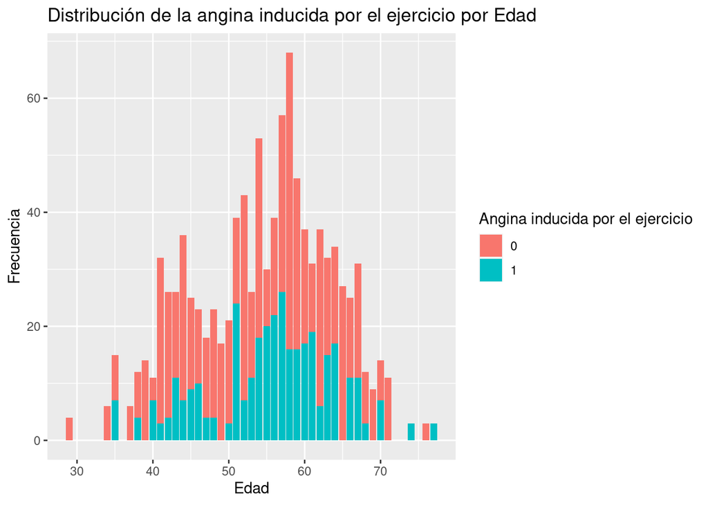

```r
ggplot(heart, aes(x = age, fill = factor(exang))) +
  geom_bar() +
  labs(x = "Edad", y = "Frecuencia", fill = "Angina inducida por el ejercicio") +
  ggtitle("Distribución de la angina inducida por el ejercicio por Edad")
```

Hay un claro aumento de la angina inducida por el ejercicio (1) conforme aumenta la edad, aunque también hay muchos pacientes que no tienen este tipo de angina. La mayoría se encuentra en el rango de edad de 50-60 años.

#### Edad-Pendiente del segmento ST de ejercicio máximo

Tabla comparativa:

```r
tabla_comparativa_edad_slope <- heart |>
  mutate(rango_edades = cut(age,breaks =8)) |>
  count(rango_edades,slope)
kable(tabla_comparativa_edad_slope)
```

| rango_edades | slope | n |
| --- | --- | --- |
| (29,35] | 1 | 4 |
| (29,35] | 2 | 21 |
| (35,41] | 0 | 3 |
| (35,41] | 1 | 23 |
| (35,41] | 2 | 49 |
| (41,47] | 0 | 10 |
| (41,47] | 1 | 66 |
| (41,47] | 2 | 78 |
| (47,53] | 0 | 11 |
| (47,53] | 1 | 59 |
| (47,53] | 2 | 99 |
| (53,59] | 0 | 29 |
| (53,59] | 1 | 153 |
| (53,59] | 2 | 111 |
| (59,65] | 0 | 14 |
| (59,65] | 1 | 109 |
| (59,65] | 2 | 75 |
| (65,71] | 0 | 7 |
| (65,71] | 1 | 65 |
| (65,71] | 2 | 30 |
| (71,77] | 1 | 3 |
| (71,77] | 2 | 6 |

Gráfico de barras:

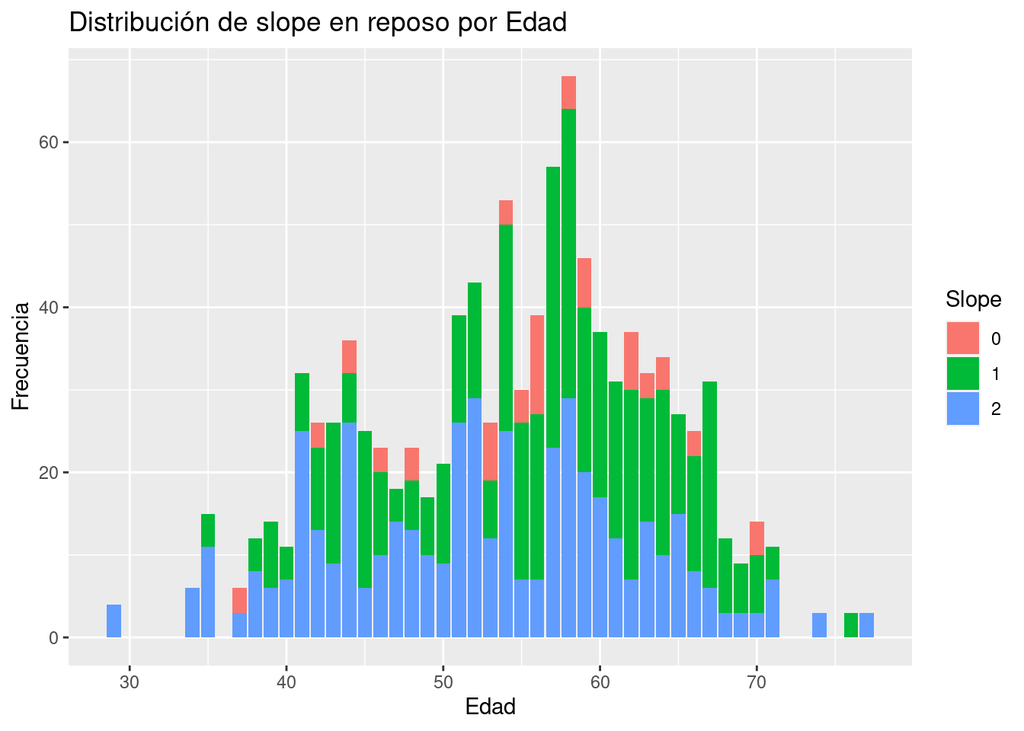

```r
ggplot(heart, aes(x = age, fill = factor(slope))) +
  geom_bar() +
  labs(x = "Edad", y = "Frecuencia", fill = "Slope") +
  ggtitle("Distribución de slope en reposo por Edad")
```

#### Edad-Número de vasos principales coloreados por fluoroscopia

Tabla comparativa:

```r
tabla_comparativa_edad_ca <- heart |>
  mutate(rango_edades = cut(age,breaks =8)) |>
  count(rango_edades,ca)
kable(tabla_comparativa_edad_ca)
```

| rango_edades | ca | n |
| --- | --- | --- |
| (29,35] | 0 | 25 |
| (35,41] | 0 | 64 |
| (35,41] | 1 | 3 |
| (35,41] | 4 | 8 |
| (41,47] | 0 | 125 |
| (41,47] | 1 | 16 |
| (41,47] | 2 | 7 |
| (41,47] | 3 | 3 |
| (41,47] | 4 | 3 |
| (47,53] | 0 | 111 |
| (47,53] | 1 | 23 |
| (47,53] | 2 | 15 |
| (47,53] | 3 | 17 |
| (47,53] | 4 | 3 |
| (53,59] | 0 | 139 |
| (53,59] | 1 | 102 |
| (53,59] | 2 | 37 |
| (53,59] | 3 | 11 |
| (53,59] | 4 | 4 |
| (59,65] | 0 | 73 |
| (59,65] | 1 | 55 |
| (59,65] | 2 | 49 |
| (59,65] | 3 | 21 |
| (65,71] | 0 | 38 |
| (65,71] | 1 | 24 |
| (65,71] | 2 | 26 |
| (65,71] | 3 | 14 |
| (71,77] | 0 | 3 |
| (71,77] | 1 | 3 |
| (71,77] | 3 | 3 |

Gráfico de barras:

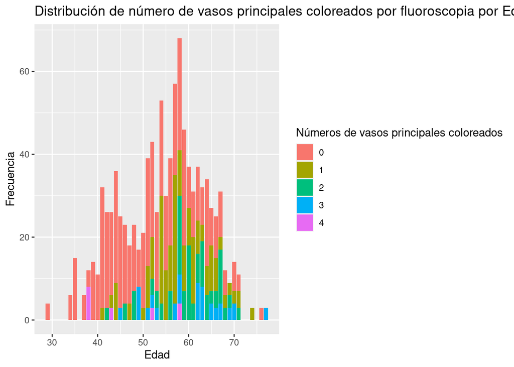

```r
ggplot(heart, aes(x = age, fill = factor(ca))) +
  geom_bar() +
  labs(x = "Edad", y = "Frecuencia", fill = "Números de vasos principales coloreados") +
  ggtitle("Distribución de número de vasos principales coloreados por fluoroscopia por Edad")
```

Se puede ver que hay muy pocos casos de 4 vasos coloreados, mientras que la mayoría tiene cero vasos coloreados. Conforme la edad aumenta aumenta también la probabilidad de que al menos un vaso principal sea coloreado (como se puede ver en la gráfica).

#### Edad-Talasemia

Tabla comparativa:

```r
tabla_comparativa_edad_thal <- heart |>
  mutate(rango_edades = cut(age,breaks =8)) |>
  count(rango_edades, thal)
kable(tabla_comparativa_edad_thal)
```

| rango_edades | thal | n |
| --- | --- | --- |
| (29,35] | 2 | 18 |
| (29,35] | 3 | 7 |
| (35,41] | 1 | 4 |
| (35,41] | 2 | 49 |
| (35,41] | 3 | 22 |
| (41,47] | 1 | 8 |
| (41,47] | 2 | 109 |
| (41,47] | 3 | 37 |
| (47,53] | 0 | 7 |
| (47,53] | 1 | 4 |
| (47,53] | 2 | 93 |
| (47,53] | 3 | 65 |
| (53,59] | 1 | 32 |
| (53,59] | 2 | 117 |
| (53,59] | 3 | 144 |
| (59,65] | 1 | 9 |
| (59,65] | 2 | 91 |
| (59,65] | 3 | 98 |
| (65,71] | 1 | 7 |
| (65,71] | 2 | 58 |
| (65,71] | 3 | 37 |
| (71,77] | 2 | 9 |

Gráfico de barras:

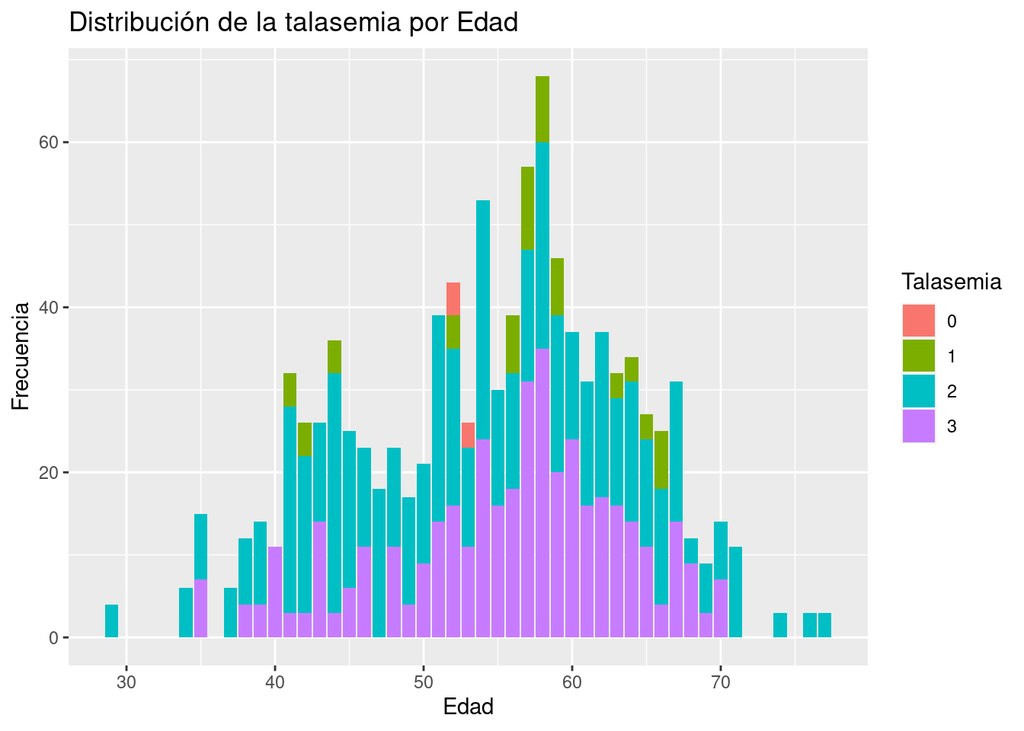

```r
ggplot(heart, aes(x = age, fill = factor(thal))) +
  geom_bar() +
  labs(x = "Edad", y = "Frecuencia", fill = "Talasemia") +
  ggtitle("Distribución de la talasemia por Edad")
```

### Sexo

Cuando las variables son categóricas no tiene sentido hacer la convalencia o la correlación, dado que las variables categóricas no son continuas.

#### Sexo-Colesterol

Tabla comparativa:

```r
tabla_comparativa_sexo_colesterol <- heart |>
  mutate(rango_colesterol=cut(chol,breaks=8)) |>
  count(sex,rango_colesterol)
kable(tabla_comparativa_sexo_colesterol)
```

| sex | rango_colesterol | n |
| --- | --- | --- |
| 0 | (126,181] | 19 |
| 0 | (181,236] | 96 |
| 0 | (236,290] | 109 |
| 0 | (290,345] | 66 |
| 0 | (345,400] | 9 |
| 0 | (400,454] | 10 |
| 0 | (509,564] | 3 |
| 1 | (126,181] | 65 |
| 1 | (181,236] | 302 |
| 1 | (236,290] | 255 |
| 1 | (290,345] | 87 |
| 1 | (345,400] | 4 |

Gráfico de cajas:

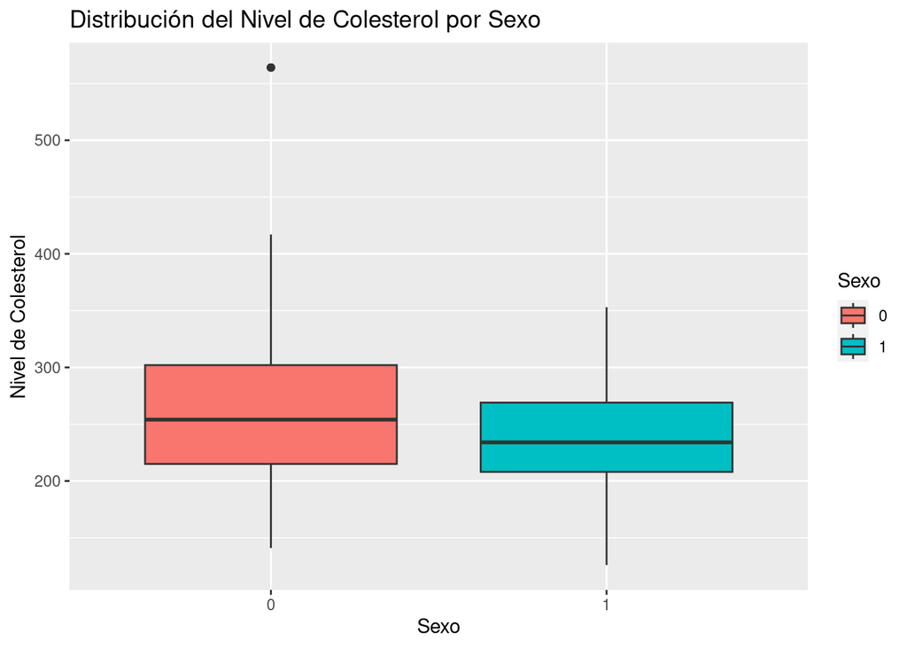

```r
ggplot(heart, aes(x = factor(sex), y = chol, fill = factor(sex))) +
  geom_boxplot() +
  labs(x = "Sexo", y = "Nivel de Colesterol", fill = "Sexo") +
  ggtitle("Distribución del Nivel de Colesterol por Sexo")
```

En esta gráfica, según la mediana (línea de en medio de la caja), las mujeres parecen tener niveles más altos que los hombres. Dado que la caja es más grande en las mujeres, hay más variabilidad en el colesterol de las mujeres que en el de los hombres. Los bigotes de la parte de las mujeres son también más grandes que el de los hombres, lo que significa que los valores de los hombres han sido más constantes. Además, hay un valor (en las mujeres) que se aleja completamente del resto de los valores (tiene el nivel de colesterol altísimo).

#### Sexo-Presión arterial en reposo

Tabla comparativa:

```r
tabla_comparativa_edad_presion_arterial <- heart |>
  mutate(rango_presion_arterial=cut(trestbps,breaks=8)) |>
  count(sex, rango_presion_arterial)
kable(tabla_comparativa_edad_presion_arterial)
```

| sex | rango_presion_arterial | n |
| --- | --- | --- |
| 0 | (93.9,107] | 21 |
| 0 | (107,120] | 69 |
| 0 | (120,134] | 74 |
| 0 | (134,147] | 84 |
| 0 | (147,160] | 42 |
| 0 | (160,174] | 4 |
| 0 | (174,187] | 14 |
| 0 | (187,200] | 4 |
| 1 | (93.9,107] | 24 |
| 1 | (107,120] | 215 |
| 1 | (120,134] | 205 |
| 1 | (134,147] | 156 |
| 1 | (147,160] | 83 |
| 1 | (160,174] | 21 |
| 1 | (174,187] | 6 |
| 1 | (187,200] | 3 |

Gráfico de cajas:

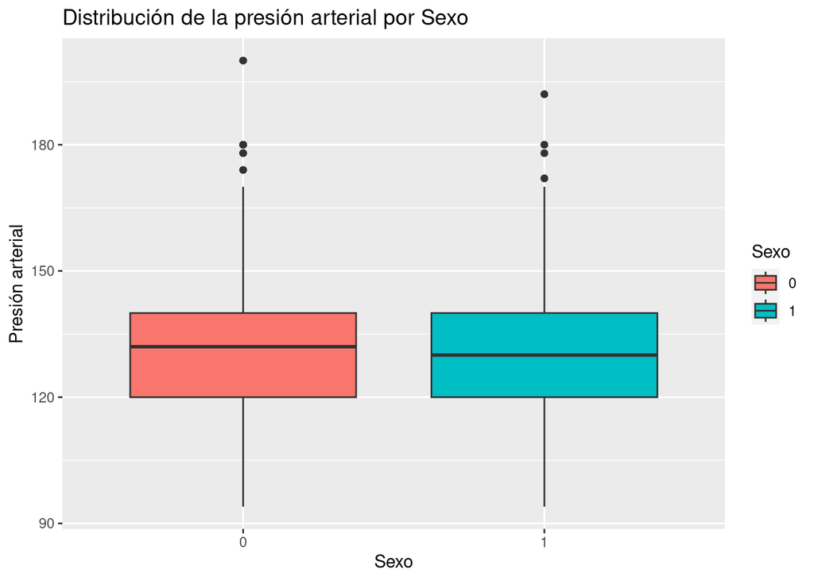

```r
ggplot(heart, aes(x = factor(sex), y = trestbps, fill = factor(sex))) +
  geom_boxplot() +
  labs(x = "Sexo", y = "Presión arterial", fill = "Sexo") +
  ggtitle("Distribución de la presión arterial por Sexo")
```

#### Sexo-Frecuencia cardiaca máxima

Tabla comparativa:

```r
tabla_comparativa_sexo_frec_cardíaca_max <- heart |>
  mutate(rango_frec_cardíaca_max=cut(thalach,breaks=8)) |>
  count(sex, rango_frec_cardíaca_max)
kable(tabla_comparativa_sexo_frec_cardíaca_max)
```

| sex | rango_frec_cardíaca_max | n |
| --- | --- | --- |
| 0 | (87.4,104] | 7 |
| 0 | (104,120] | 23 |
| 0 | (120,136] | 45 |
| 0 | (136,153] | 68 |
| 0 | (153,169] | 115 |
| 0 | (169,186] | 51 |
| 0 | (186,202] | 3 |
| 1 | (70.9,87.4] | 4 |
| 1 | (87.4,104] | 25 |
| 1 | (104,120] | 71 |
| 1 | (120,136] | 103 |
| 1 | (136,153] | 177 |
| 1 | (153,169] | 180 |
| 1 | (169,186] | 127 |
| 1 | (186,202] | 26 |

Gráfico de cajas:

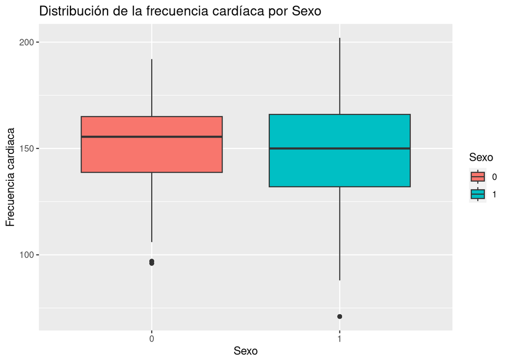

```r
ggplot(heart, aes(x = factor(sex), y = thalach, fill = factor(sex))) +
  geom_boxplot() +
  labs(x = "Sexo", y = "Frecuencia cardiaca", fill = "Sexo") +
  ggtitle("Distribución de la frecuencia cardíaca por Sexo")
```

En esta gráfica, según la mediana, las mujeres parecen tener la frecuencia más alta que los hombres. Dado que la caja es más grande en los hombres, hay más variabilidad en la frecuencia cardíaca de los hombres que en el de las mujeres. Los bigotes de la caja de los hombres son mayores, lo que sugiere que la frecuencia cardíaca de las mujeres es más constante. Además, hay dos valores valores, (el de la mujer más alto que el del hombre), que se alejan completamente del resto de los valores (frecuencia arterial más baja).